# Project "Boston housing"

Stanin Vladislav

```python
import pandas as pd
import numpy as np
import seaborn as sns
import matplotlib.pyplot as plt
import statsmodels.api as sm

from scipy.stats import ttest_ind, ttest_rel, mannwhitneyu, pearsonr
```

### Data installation

```python
data  = pd.read_csv('../data/BostonHousing.csv')
data
```

|  | crim | zn | indus | chas | nox | rm | age | dis | rad | tax | ptratio | b | lstat | medv |
| --- | --- | --- | --- | --- | --- | --- | --- | --- | --- | --- | --- | --- | --- | --- |
| 0 | 0.00632 | 18.0 | 2.31 | 0 | 0.538 | 6.575 | 65.2 | 4.0900 | 1 | 296 | 15.3 | 396.90 | 4.98 | 24.0 |
| 1 | 0.02731 | 0.0 | 7.07 | 0 | 0.469 | 6.421 | 78.9 | 4.9671 | 2 | 242 | 17.8 | 396.90 | 9.14 | 21.6 |
| 2 | 0.02729 | 0.0 | 7.07 | 0 | 0.469 | 7.185 | 61.1 | 4.9671 | 2 | 242 | 17.8 | 392.83 | 4.03 | 34.7 |
| 3 | 0.03237 | 0.0 | 2.18 | 0 | 0.458 | 6.998 | 45.8 | 6.0622 | 3 | 222 | 18.7 | 394.63 | 2.94 | 33.4 |
| 4 | 0.06905 | 0.0 | 2.18 | 0 | 0.458 | 7.147 | 54.2 | 6.0622 | 3 | 222 | 18.7 | 396.90 | 5.33 | 36.2 |
| ... | ... | ... | ... | ... | ... | ... | ... | ... | ... | ... | ... | ... | ... | ... |
| 501 | 0.06263 | 0.0 | 11.93 | 0 | 0.573 | 6.593 | 69.1 | 2.4786 | 1 | 273 | 21.0 | 391.99 | 9.67 | 22.4 |
| 502 | 0.04527 | 0.0 | 11.93 | 0 | 0.573 | 6.120 | 76.7 | 2.2875 | 1 | 273 | 21.0 | 396.90 | 9.08 | 20.6 |
| 503 | 0.06076 | 0.0 | 11.93 | 0 | 0.573 | 6.976 | 91.0 | 2.1675 | 1 | 273 | 21.0 | 396.90 | 5.64 | 23.9 |
| 504 | 0.10959 | 0.0 | 11.93 | 0 | 0.573 | 6.794 | 89.3 | 2.3889 | 1 | 273 | 21.0 | 393.45 | 6.48 | 22.0 |
| 505 | 0.04741 | 0.0 | 11.93 | 0 | 0.573 | 6.030 | 80.8 | 2.5050 | 1 | 273 | 21.0 | 396.90 | 7.88 | 11.9 |

506 rows × 14 columns

### little EDA

```python
data.info()
```

```
<class 'pandas.core.frame.DataFrame'>
RangeIndex: 506 entries, 0 to 505
Data columns (total 14 columns):
 #   Column   Non-Null Count  Dtype
---  ------   --------------  -----
 0   crim     506 non-null    float64
 1   zn       506 non-null    float64
 2   indus    506 non-null    float64
 3   chas     506 non-null    int64
 4   nox      506 non-null    float64
 5   rm       506 non-null    float64
 6   age      506 non-null    float64
 7   dis      506 non-null    float64
 8   rad      506 non-null    int64
 9   tax      506 non-null    int64
 10  ptratio  506 non-null    float64
 11  b        506 non-null    float64
 12  lstat    506 non-null    float64
 13  medv     506 non-null    float64
dtypes: float64(11), int64(3)
memory usage: 55.5 KB
```

```python
data.isna().sum()
```

```
crim       0
zn         0
indus      0
chas       0
nox        0
rm         0
age        0
dis        0
rad        0
tax        0
ptratio    0
b          0
lstat      0
medv       0
dtype: int64
```

**No problems with data**

#### Distribution of target variable (*medv*):

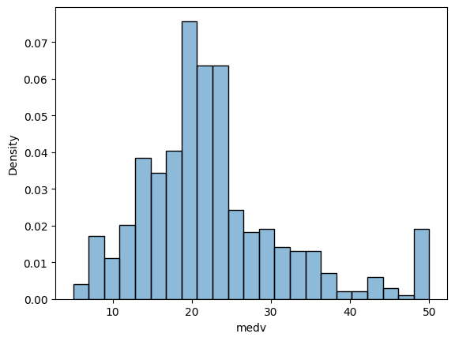

```python
sns.histplot(data[['medv']], stat='density', color='blue', legend=False);
plt.xlabel('medv');
```

```python
predictors = data.iloc[:,:-1]
medv = data.iloc[:,-1]
```

## Standartization

```python
means = predictors.mean(axis=0)
stds = predictors.std(axis=0)

scaled_preds = (predictors - means) / stds

scaled_preds.head()
```

|  | crim | zn | indus | chas | nox | rm | age | dis | rad | tax | ptratio | b | lstat |
| --- | --- | --- | --- | --- | --- | --- | --- | --- | --- | --- | --- | --- | --- |
| 0 | -0.419367 | 0.284548 | -1.286636 | -0.272329 | -0.144075 | 0.413263 | -0.119895 | 0.140075 | -0.981871 | -0.665949 | -1.457558 | 0.440616 | -1.074499 |
| 1 | -0.416927 | -0.487240 | -0.592794 | -0.272329 | -0.739530 | 0.194082 | 0.366803 | 0.556609 | -0.867024 | -0.986353 | -0.302794 | 0.440616 | -0.491953 |
| 2 | -0.416929 | -0.487240 | -0.592794 | -0.272329 | -0.739530 | 1.281446 | -0.265549 | 0.556609 | -0.867024 | -0.986353 | -0.302794 | 0.396035 | -1.207532 |
| 3 | -0.416338 | -0.487240 | -1.305586 | -0.272329 | -0.834458 | 1.015298 | -0.809088 | 1.076671 | -0.752178 | -1.105022 | 0.112920 | 0.415751 | -1.360171 |
| 4 | -0.412074 | -0.487240 | -1.305586 | -0.272329 | -0.834458 | 1.227362 | -0.510674 | 1.076671 | -0.752178 | -1.105022 | 0.112920 | 0.440616 | -1.025487 |

## First linear model

```python
X = sm.add_constant(scaled_preds)
model_scaled = sm.OLS(medv, X)
results_scaled = model_scaled.fit()

print(results_scaled.summary())
```

```
                            OLS Regression Results
==============================================================================
Dep. Variable:                   medv   R-squared:                       0.741
Model:                            OLS   Adj. R-squared:                  0.734
Method:                 Least Squares   F-statistic:                     108.1
Date:                Tue, 13 Dec 2022   Prob (F-statistic):          6.72e-135
Time:                        14:51:45   Log-Likelihood:                -1498.8
No. Observations:                 506   AIC:                             3026.
Df Residuals:                     492   BIC:                             3085.
Df Model:                          13
Covariance Type:            nonrobust
==============================================================================
                 coef    std err          t      P>|t|      [0.025      0.975]
------------------------------------------------------------------------------
const         22.5328      0.211    106.814      0.000      22.118      22.947
crim          -0.9291      0.283     -3.287      0.001      -1.484      -0.374
zn             1.0826      0.320      3.382      0.001       0.454       1.712
indus          0.1410      0.422      0.334      0.738      -0.688       0.970
chas           0.6824      0.219      3.118      0.002       0.252       1.112
nox           -2.0588      0.443     -4.651      0.000      -2.928      -1.189
rm             2.6769      0.294      9.116      0.000       2.100       3.254
age            0.0195      0.372      0.052      0.958      -0.711       0.750
dis           -3.1071      0.420     -7.398      0.000      -3.932      -2.282
rad            2.6649      0.578      4.613      0.000       1.530       3.800
tax           -2.0788      0.634     -3.280      0.001      -3.324      -0.834
ptratio       -2.0626      0.283     -7.283      0.000      -2.619      -1.506
b              0.8501      0.245      3.467      0.001       0.368       1.332
lstat         -3.7473      0.362    -10.347      0.000      -4.459      -3.036
==============================================================================
Omnibus:                      178.041   Durbin-Watson:                   1.078
Prob(Omnibus):                  0.000   Jarque-Bera (JB):              783.126
Skew:                           1.521   Prob(JB):                    8.84e-171
Kurtosis:                       8.281   Cond. No.                         9.82
==============================================================================

Notes:
[1] Standard Errors assume that the covariance matrix of the errors is correctly specified.
```

**The *age* and *indus* predictors not significantly predicts the *medv***  
*Checking model without these predictors:*

```python
model_new = sm.OLS(medv, X.drop(columns=["indus", "age"]))
results_new = model_new.fit()

print(results_new.summary())
```

```
                            OLS Regression Results
==============================================================================
Dep. Variable:                   medv   R-squared:                       0.741
Model:                            OLS   Adj. R-squared:                  0.735
Method:                 Least Squares   F-statistic:                     128.2
Date:                Tue, 13 Dec 2022   Prob (F-statistic):          5.54e-137
Time:                        14:51:45   Log-Likelihood:                -1498.9
No. Observations:                 506   AIC:                             3022.
Df Residuals:                     494   BIC:                             3072.
Df Model:                          11
Covariance Type:            nonrobust
==============================================================================
                 coef    std err          t      P>|t|      [0.025      0.975]
------------------------------------------------------------------------------
const         22.5328      0.211    107.018      0.000      22.119      22.946
crim          -0.9325      0.282     -3.307      0.001      -1.486      -0.379
zn             1.0692      0.315      3.390      0.001       0.450       1.689
chas           0.6905      0.217      3.183      0.002       0.264       1.117
nox           -2.0135      0.410     -4.915      0.000      -2.818      -1.209
rm             2.6711      0.285      9.356      0.000       2.110       3.232
dis           -3.1432      0.391     -8.037      0.000      -3.912      -2.375
rad            2.6088      0.552      4.726      0.000       1.524       3.693
tax           -1.9850      0.568     -3.493      0.001      -3.102      -0.868
ptratio       -2.0492      0.279     -7.334      0.000      -2.598      -1.500
b              0.8482      0.244      3.475      0.001       0.369       1.328
lstat         -3.7316      0.339    -11.019      0.000      -4.397      -3.066
==============================================================================
Omnibus:                      178.430   Durbin-Watson:                   1.078
Prob(Omnibus):                  0.000   Jarque-Bera (JB):              787.785
Skew:                           1.523   Prob(JB):                    8.60e-172
Kurtosis:                       8.300   Cond. No.                         7.90
==============================================================================

Notes:
[1] Standard Errors assume that the covariance matrix of the errors is correctly specified.
```

Model did not changed significantly arfter removing those predictors.  
Nevertheless, F-statistics and R-adj were increased (and p-val decreased).  
In the rest of report i will name these paramters as **Statistics** (If they become better, I will say that Statistics *increased*)

```python
X_new = X.drop(columns=["indus", "age"])
```

## Checking model

### Linear relationship

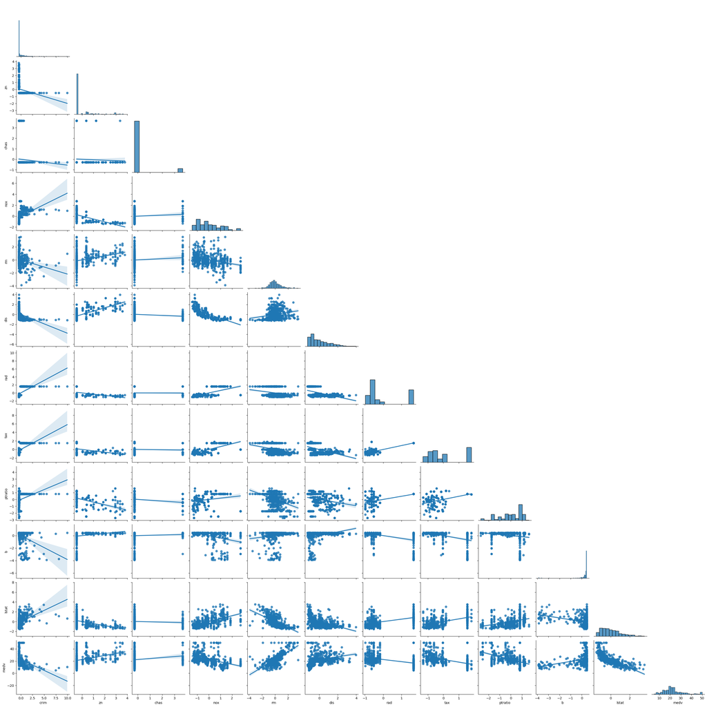

```python
fig = sns.pairplot(pd.concat([scaled_preds.drop(columns=["indus", "age"]), medv], axis=1), kind="reg", corner=True);
fig.savefig("pairplot.png");
```

**Most of predictors have linear relationship with *medv*, but *lstat* which have looking like exponental relationship**  
Let's check:

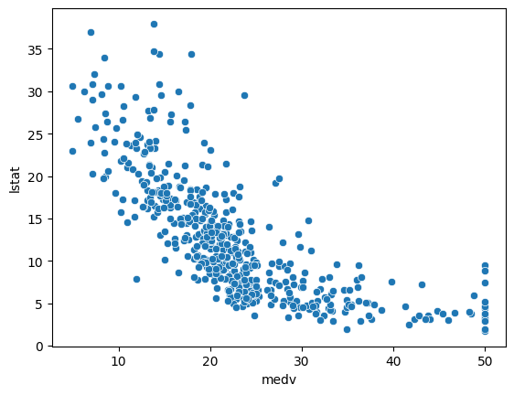

```python
sns.scatterplot(y=predictors.lstat,
                x=medv);
```

```python
print(f"medv and lstat correlated with Pearson\'s r value {pearsonr(y=predictors.lstat, x=medv).statistic} and pvalue {pearsonr(y=predictors.lstat, x=medv).pvalue}")
```

```
medv and lstat correlated with Pearson's r value -0.737662726174015 and pvalue 5.081103394386392e-88
```

**Checking relationship between *lstat* and *-ln(medv)***

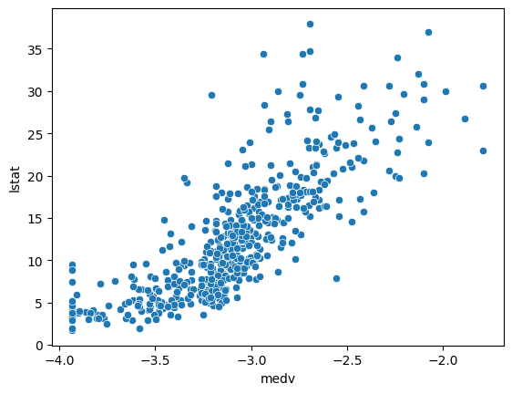

```python
sns.scatterplot(y=predictors.lstat,
                x=-np.log(medv+1));
```

```python
print(f'ln(medv) and lstat correlated with Pearson\'s r value {pearsonr(y=predictors.lstat, x=np.log(medv+1)).statistic.round(4)} and pvalue {pearsonr(y=predictors.lstat, x=np.log(medv+1)).pvalue}')
```

```
ln(medv) and lstat correlated with Pearson's r value -0.8043 and pvalue 5.230310856128727e-116
```

**Since Pearson's r not changed significantly, we can leave it**  
However,  
Additional check of model without *lstat* predictor:

```python
model_wo_lstat = sm.OLS(medv, X_new.drop(columns=["lstat"]))
results_wo_lstat = model_wo_lstat.fit()

print(results_wo_lstat.summary())
```

```
                            OLS Regression Results
==============================================================================
Dep. Variable:                   medv   R-squared:                       0.677
Model:                            OLS   Adj. R-squared:                  0.670
Method:                 Least Squares   F-statistic:                     103.7
Date:                Tue, 13 Dec 2022   Prob (F-statistic):          1.33e-114
Time:                        14:52:35   Log-Likelihood:                -1554.5
No. Observations:                 506   AIC:                             3131.
Df Residuals:                     495   BIC:                             3177.
Df Model:                          10
Covariance Type:            nonrobust
==============================================================================
                 coef    std err          t      P>|t|      [0.025      0.975]
------------------------------------------------------------------------------
const         22.5328      0.235     95.979      0.000      22.072      22.994
crim          -1.4336      0.310     -4.621      0.000      -2.043      -0.824
zn             1.0549      0.352      3.000      0.003       0.364       1.746
chas           0.7784      0.242      3.220      0.001       0.303       1.253
nox           -2.9458      0.447     -6.591      0.000      -3.824      -2.068
rm             4.2960      0.273     15.761      0.000       3.760       4.831
dis           -2.7631      0.434     -6.361      0.000      -3.617      -1.910
rad            2.6869      0.616      4.365      0.000       1.478       3.896
tax           -2.1965      0.633     -3.468      0.001      -3.441      -0.952
ptratio       -2.3219      0.310     -7.482      0.000      -2.932      -1.712
b              1.2392      0.269      4.602      0.000       0.710       1.768
==============================================================================
Omnibus:                      247.217   Durbin-Watson:                   0.948
Prob(Omnibus):                  0.000   Jarque-Bera (JB):             2087.021
Skew:                           1.949   Prob(JB):                         0.00
Kurtosis:                      12.154   Cond. No.                         7.46
==============================================================================

Notes:
[1] Standard Errors assume that the covariance matrix of the errors is correctly specified.
```

**Statistics of model decresed, therefore we leave *lstat* predictor in model**

### Checking if distribution of residuals is normal

```python
prediction = results_new.get_prediction(X_new)
medv_predicted = prediction.predicted_mean
```

```python
residuals = medv - medv_predicted
```

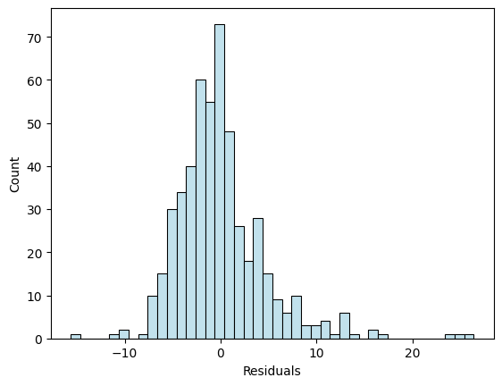

```python
sns.histplot(residuals, color='lightblue', binwidth=1);
plt.xlabel('Residuals');
```

**Seems like normal...**

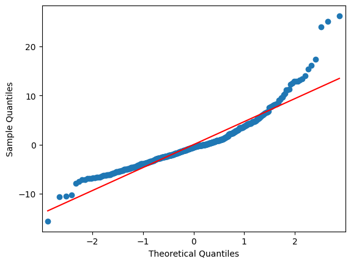

```python
sm.qqplot(residuals, line='s');
```

**Still lloks like normal, with some deviations (richest houses)**  
**but let's check these deviations:**

### Checking devations

(Calculating Cook's distances)

```python
influence = results_new.get_influence()
cooks = influence.cooks_distance
n_deviations = (cooks[1] < 0.05).sum()
print(f'There are {n_deviations} significant deviations')
```

```
There are 0 significant deviations
```

**There are no deviations!**

### Checking homoscedacity

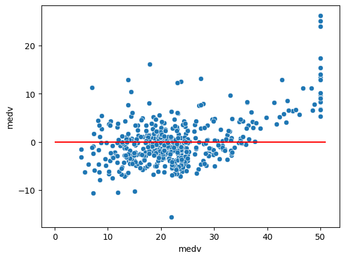

```python
sns.scatterplot(x = medv, y = residuals);
plt.hlines(0,0, 51, color = 'red');
```

**Only some very expensive houses deviate. Nevertheless, we can consider that the model has homoscedasticity**

### Checking VIF

```python
from statsmodels.stats.outliers_influence import variance_inflation_factor
```

```python
def vif(preds):
    vif_data = pd.DataFrame()
    vif_data["Predictor"] = preds.columns
    vif_data["VIF"] = [variance_inflation_factor(preds.values, i) for i in range(len(preds.columns))]
    return vif_data
```

```python
vif(X_new)
```

|  | Predictor | VIF |
| --- | --- | --- |
| 0 | const | 1.000000 |
| 1 | crim | 1.789704 |
| 2 | zn | 2.239229 |
| 3 | chas | 1.059819 |
| 4 | nox | 3.778011 |
| 5 | rm | 1.834806 |
| 6 | dis | 3.443420 |
| 7 | rad | 6.861126 |
| 8 | tax | 7.272386 |
| 9 | ptratio | 1.757681 |
| 10 | b | 1.341559 |
| 11 | lstat | 2.581984 |

**There are several predictors that is linked with others**

```python
X_new_2 = X_new.drop(columns=["tax"])
vif(X_new_2)
```

|  | Predictor | VIF |
| --- | --- | --- |
| 0 | const | 1.000000 |
| 1 | crim | 1.787963 |
| 2 | zn | 2.154054 |
| 3 | chas | 1.052428 |
| 4 | nox | 3.564036 |
| 5 | rm | 1.806735 |
| 6 | dis | 3.410587 |
| 7 | rad | 2.776775 |
| 8 | ptratio | 1.717222 |
| 9 | b | 1.338982 |
| 10 | lstat | 2.579040 |

*It looks much better*  
VIF of *rad* reduced significantly and it means thar *tax* and *rad* was linked

#### Checking new model without *tax*

```python
model_new_2 = sm.OLS(medv, X_new_2)
results_new_2 = model_new_2.fit()

print(results_new_2.summary())
```

```
                            OLS Regression Results
==============================================================================
Dep. Variable:                   medv   R-squared:                       0.734
Model:                            OLS   Adj. R-squared:                  0.729
Method:                 Least Squares   F-statistic:                     136.7
Date:                Tue, 13 Dec 2022   Prob (F-statistic):          1.84e-135
Time:                        14:52:36   Log-Likelihood:                -1505.0
No. Observations:                 506   AIC:                             3032.
Df Residuals:                     495   BIC:                             3079.
Df Model:                          10
Covariance Type:            nonrobust
==============================================================================
                 coef    std err          t      P>|t|      [0.025      0.975]
------------------------------------------------------------------------------
const         22.5328      0.213    105.828      0.000      22.114      22.951
crim          -0.9018      0.285     -3.164      0.002      -1.462      -0.342
zn             0.8544      0.313      2.731      0.007       0.240       1.469
chas           0.7538      0.219      3.448      0.001       0.324       1.183
nox           -2.3540      0.402     -5.850      0.000      -3.145      -1.563
rm             2.7944      0.286      9.754      0.000       2.232       3.357
dis           -3.0098      0.394     -7.647      0.000      -3.783      -2.236
rad            1.1212      0.355      3.157      0.002       0.423       1.819
ptratio       -2.1972      0.279     -7.867      0.000      -2.746      -1.648
b              0.8856      0.247      3.591      0.000       0.401       1.370
lstat         -3.7715      0.342    -11.019      0.000      -4.444      -3.099
==============================================================================
Omnibus:                      166.907   Durbin-Watson:                   1.090
Prob(Omnibus):                  0.000   Jarque-Bera (JB):              684.418
Skew:                           1.441   Prob(JB):                    2.40e-149
Kurtosis:                       7.915   Cond. No.                         5.02
==============================================================================

Notes:
[1] Standard Errors assume that the covariance matrix of the errors is correctly specified.
```

### The largest modulo value of coefficient belongs to *lstat* predictor

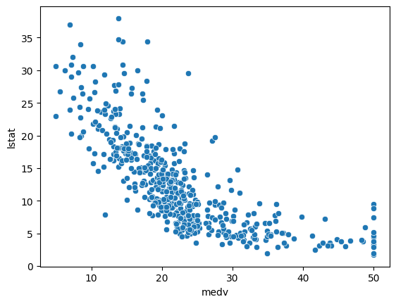

```python
sns.scatterplot(x = medv, y = predictors.lstat);
```

#### *lstat* vs predicted *medv*

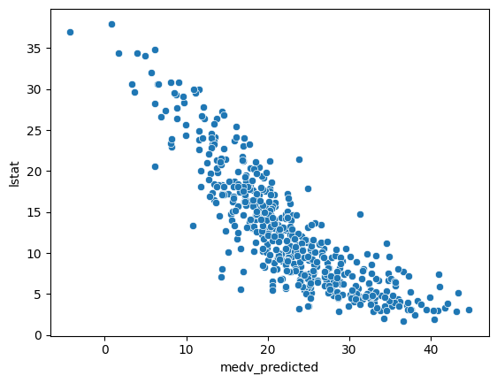

```python
sns.scatterplot(x = medv_predicted, y = predictors.lstat);
plt.xlabel('medv_predicted');
```